# EXPLICABILIDAD

La **explicabilidad** en el contexto de Machine Learning se refiere a la capacidad de comprender y explicar de manera clara y comprensible cómo un modelo toma decisiones o hace predicciones. A medida que los modelos de Machine Learning se vuelven más complejos, como es el caso de las redes neuronales profundas o algoritmos de aprendizaje automático avanzados, entender cómo y por qué toman ciertas decisiones se vuelve crucial, especialmente en aplicaciones críticas como la atención médica y la justicia, entre otras. [Información adicional](https://christophm.github.io/interpretable-ml-book/)

En este notebook se va a incluir **la técnica de explicabilidad SHAP (SHapley Additive exPlanations)** puesto que se trata de una herramienta poderosa para entender, interpretar y mejorar modelos de aprendizaje automático, como es en este caso nuestro **modelo ganador LightGBM**. Además, consideramos crucial incluir este apartado dentro del trabajo debido a que la herramienta SHAP contribuye a aspectos cada vez más importantes en la adopción de la inteligencia artificial en aplicaciones del mundo real como son la explicabilidad y **transparencia de los modelos**.

Por último, se muestra **la importancia de las variables en el mejor modelo LightGBM** encontrado durante este proceso para poder comprobar qué variables son más influyentes en las predicciones del modelo.

### Librerías

En primer lugar, se importan las librerías necesarias y se cargan los datos guardados en los notebooks previos.

```python
import pandas as pd
import numpy as np
import matplotlib.pyplot as plt
import seaborn as sns
import pickle
import sklearn
from sklearn import metrics
from sklearn.pipeline import Pipeline
from sklearn.compose import ColumnTransformer
from xgboost import XGBClassifier
import shap
shap.initjs()
import warnings
warnings.filterwarnings('ignore')
from sklearn.inspection import permutation_importance
from sklearn.ensemble import AdaBoostClassifier
```

```python
#!pip install shap
```

Leemos los archivos de test.

```python
X_test_def = pd.read_csv("data/X_test_def.csv")
y_test_def = pd.read_csv("data/y_test_def.csv")
```

Se elimina de los dos archivos la columna "Unnamed: 0" puesto que se genera automáticamente al guardar los documentos csv pero no es de interés en este trabajo

```python
X_test_def = X_test_def.drop(columns=["Unnamed: 0"])
y_test_def = y_test_def.drop(columns=["Unnamed: 0"])
```

Cargamos el mejor modelo elegido en el notebook 8, el modelo LightGBM

```python
with open('lgbm.pkl', 'rb') as file:
    lgbm = pickle.load(file)
```

## SHAP

SHAP (SHapley Additive exPlanations) es una técnica de explicabilidad en aprendizaje automático que se basa en la teoría de juegos y en los valores de Shapley. SHAP values proporciona una forma consistente y teóricamente sólida de asignar contribuciones a cada característica en el modelo de machine learning, permitiendo interpretar la salida del modelo de manera individualizada (local) y global.

[Información adicional](https://shap.readthedocs.io/en/latest/generated/shap.TreeExplainer.html)

[Información adicional](https://github.com/shap/shap)

En primer lugar, en una nueva variable llamada 'lgbm_model' asignamos el mejor modelo de LightGBM

```python
lgbm_model = lgbm.best_estimator_
```

A continuación se crea una variable 'explainer' para explicar las predicciones del modelo LightGBM ('lgbm_model'). De esta forma se calcularán los valores Shapley, es decir, la contribución de cada característica a las predicciones del modelo:

```python
explainer = shap.TreeExplainer(lgbm_model)
```

Se calculan los valores Shapley para cada instancia en 'X_test_def', almacenando el resultado en la variable 'shap_values'.

```python
shap_values = explainer.shap_values(X_test_def)
```

A continuación se visualiza la contribución de cada característica a la predicción del modelo para una instancia específica en el conjunto de datos de prueba

```python
shap.force_plot(explainer.expected_value[0], shap_values[0][0], X_test_def.iloc[0,:])
```

[output not shown]

- 'email_is_free'=0, es decir, la cuenta de correo es gratuita.
- 'housing_status'=2, al ser una variable anonimizada no se puede especificar qué tipo de categoría es.
- 'name_email_similarity'=0.6506, una similitud del correo electrónico y el nombre del solicitante de 0.6506 (variable acotada entre 0 y 1).

- 'device_os'=0, es decir, el sistema operativo del dispositivo con el que se hizo la solicitud es Windows.
- 'income'=0.9, el ingreso anual del solcitante máximo en esta escala (variable acotada de 0.1 a 0.9).
- 'current_address_months_count'=61, el solicitante lleva 61 meses en la dirección actual registrada (5 años y casi 1 mes).
- 'phone_home_valid'=0, el teléfono fijo proporcionado no es válido.

Por tanto, la posición de la barra con respecto a la línea base ('explainer.expected_value[0]') indica la dirección y magnitud de la contribución de esa característica específica. Si la barra es roja contribuye positivamente a la predicción y si es azul contribuye negativamente.

A continuación se muestra un gráfico resumen de las contribuciones de todas las características en el conjunto de datos de prueba ('X_test_def'). Cada barra horizontal representa la suma de los valores SHAP absolutos para una característica específica:

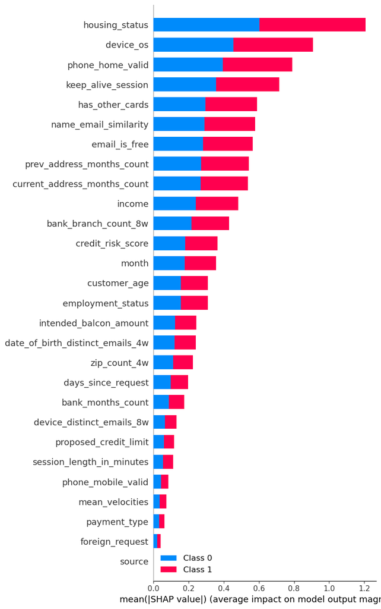

```python
shap.summary_plot(shap_values, X_test_def,max_display=X_test_def.shape[1])
```

En el gráfico superior se observa la importancia total de cada característica en todas las instancias del conjunto de datos de prueba, mostrándose que **la mayor importancia es poseída por la variable 'housing_status'(alrededor de 1.2) seguida de 'device_os' y 'phone_home_valid'**.

Por el contrario las **variables 'source', 'foreign_request' y 'payment_type' son las variables con menor importancia total en las instancias del test**. Como se comprobará posteriormente, **estas variables coinciden con las menos importantes según el análisis de importancia que se realizará en el último apartado** (con la librería Sklearn).

En la siguiente línea de código se crea un gráfico resumen específico para la clase 1 en el problema de clasificación:

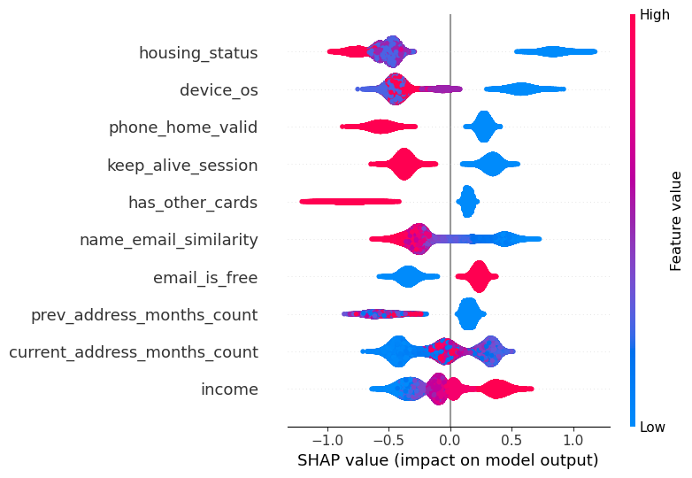

```python
shap.summary_plot(shap_values[1], features=X_test_def, max_display=10)
```

En las variables **'housing_status', 'device_os', 'name_email_similarity' y 'prev_adress_months_count'** a simple vista se podría afirmar que cuando toman valores bajos contribuyen en mayor medida a que la solicitud sea fraudulenta; sin embargo, dado que tienen puntos solapados de ambos colores por debajo de 0 **tanto valores altos como bajos de estas variables hacen que la probabilidad de que sea fraude la solicitud sea más alta o baja**. Por ejemplo, que el grado de similitud del nombre y el correo eléctronico del solicitante sea bajo puede tanto contribuir en mayor como menor medida a que la solicitud sea fraudulenta (dependiendo del caso).

Al contrario que en el caso anterior, con las variables **'current_adress_months_count' e 'income'** valores altos contribuyen a que la solicitud sea fraudulenta pero a su vez, puesto que existen puntos solapados de ambos colores por debajo de 0, **tanto valores altos como bajos de estas variables hacen que la probabilidad de que sea fraude la solicitud sea más alta o baja**. Por ejemplo, que los ingresos del solicitante sean altos puede tanto contribuir en mayor como menor medida a que la solicitud sea fraudulenta (dependiendo del caso).

Por tanto, existen distintos comportamientos en función de los valores de cada variable sobre la variable target 'fraud_bool'.

## Explicabilidad con Sklearn

Por último, se visualiza la importancia de las variables en el mejor modelo LightGBM encontrado durante el proceso, proporcionando una representación gráfica de qué variables son más influyentes en las predicciones del modelo:

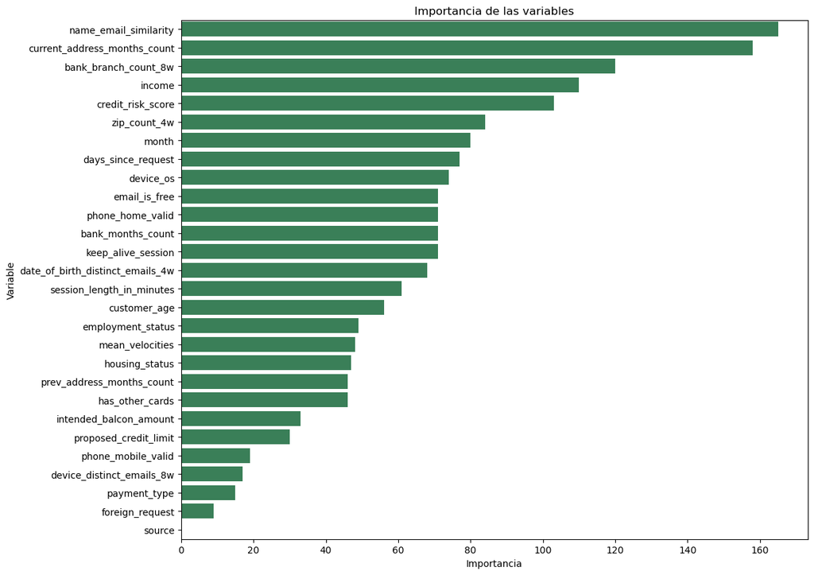

```python
model = lgbm.best_estimator_
important_variables = model.feature_importances_
feature_names = X_test_def.columns
importancia_variables = sorted(zip(feature_names, important_variables), key=lambda tup: tup[1], reverse=True)
importancia_variables_df = pd.DataFrame(importancia_variables, columns=['Variable', 'Importancia'])
plt.figure(figsize=(12, 10))
sns.barplot(x='Importancia', y='Variable', data=importancia_variables_df, color='seagreen')
plt.title('Importancia de las variables')
plt.show()
```

Se observa que las **variables con mayor importancia dentro del modelo son: 'name_email_similarity', 'current_adress_months_count' y 'bank_branch_count_8w'**. Por el contrario, las variables que presentan una menor importancia dentro de este análisis son: 'source', 'foreign_request' y 'payment_type'. Además, se puede comprobar que existe una gran diferencia entre la importancia otorgada a estos dos grupos de variables (source tiene una importancia nula mientras que 'name_email_similarity' próxima a 160).

Cabe destacar que:

- Las variables más importantes en el modelo LightGBM son las que tienen un **mayor impacto en las predicciones del modelo**.
- Aunque 'name_email_similarity' tenga una alta importancia en el modelo LightGBM, no significa necesariamente que sea causal en relación con la variable objetivo 'fraud_bool' puesto que **la correlación no implica causalidad**.

Como recordatorio, las variables más importantes según este análisis tienen los siguientes significados tal y como indica el diccionario de datos:

- **'name_email_similarity'**: Metric of similarity between email and applicant’s name. Higher values represent higher similarity. Ranges between [0,1].
- **'current_adress_months_count'**: Months in currently registered address of the applicant. Ranges between [−1, 429] months (-1 is a missing value).
- **'bank_branch_count_8w'**: bank_branch_count_8w (numeric): Number of total applications in the selected bank branch in last 8 weeks. Ranges between [0, 2404].

## Conclusiones

De esta forma, no solo se ha seleccionado un modelo ganadar para el problema objeto de este trabajo sino que también se ha tratado de explicar con dicho modelo (LightGBM) la importancia de las variables 'finales' (tras realizar las tareas de preporcesamiento, imputación de missings, combinación y eliminación de variables etcétera).